# STOR 455 Extra Credit HW. Due 04/30 11:55pm. Submit through Sakai Assignments.

```r
library(Stat2Data)
library(car)
library(agricolae)
data(Sparrows)
data(Caterpillars)
data(Retirement)
data(Cereal)
data(LewyDLBad)
data(USstamps)
data(MathEnrollment)
data(BrainpH)
data(Jurors)
data(Handwriting)
data(ElephantsFB)
data(NCbirths)
data(Blood1)
data(MouseBrain)
data(NCbirths)
data(AutoPollution)
```

Page 175

```r
# Chapter 1 Exercises
# 3, 5, 23, 27, 31, 47
```

```r
# Exercise 3
SparrowModel = lm(Weight~WingLength, data = Sparrows)
SparrowModel$coefficients[2]
```

```
WingLength
  0.467404
```

```r
# Exercise 5
SparrowModel$coefficients[1]
```

```
(Intercept)
    1.36549
```

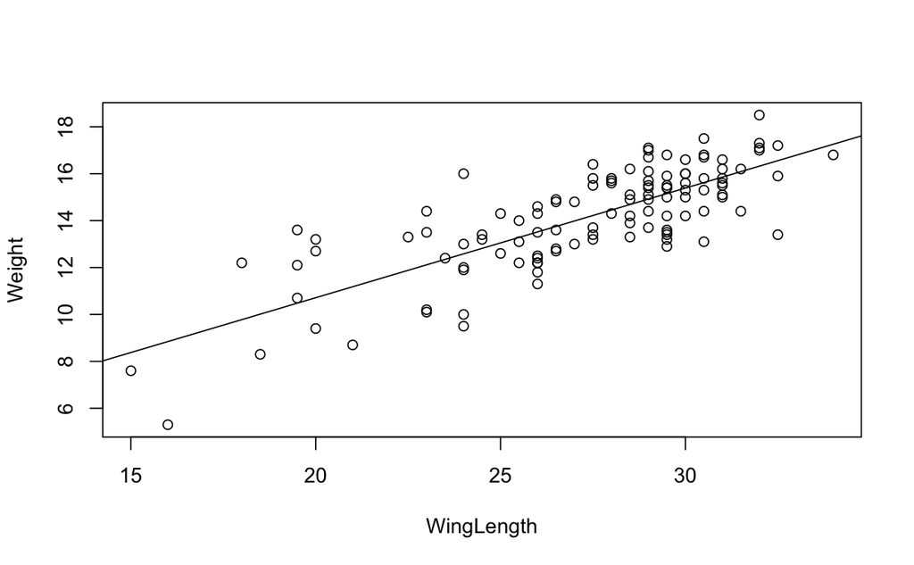

```r
# Exercise 23
plot(Weight~WingLength, data = Sparrows)
abline(SparrowModel)
```

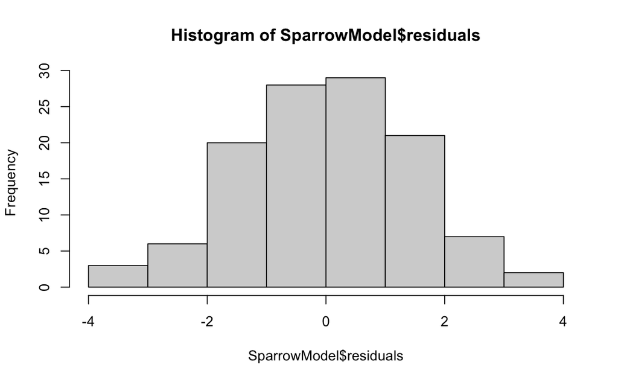

```r
hist(SparrowModel$residuals)
```

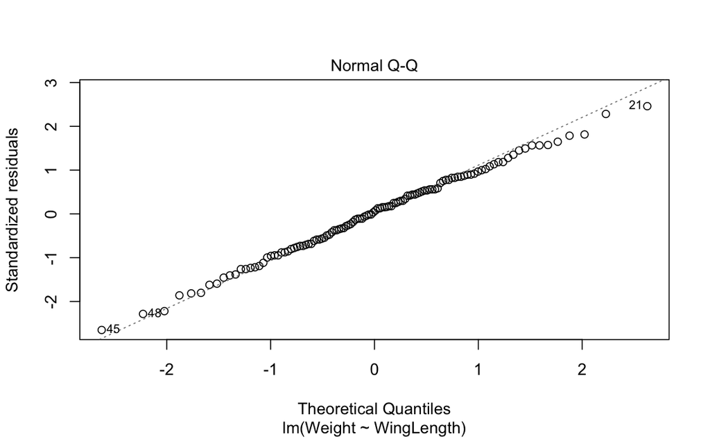

```r
plot(SparrowModel, 2)
```

Looking on the plot with the LSRL line there doesn’t appear to be any significant outliers. The residual plot looks good and normal as the shape of the histogram is a bell curve. When looking at the qqplot the points are relatively linear indicating normality. Through all of these conditions a linear model seems to match the data very well.

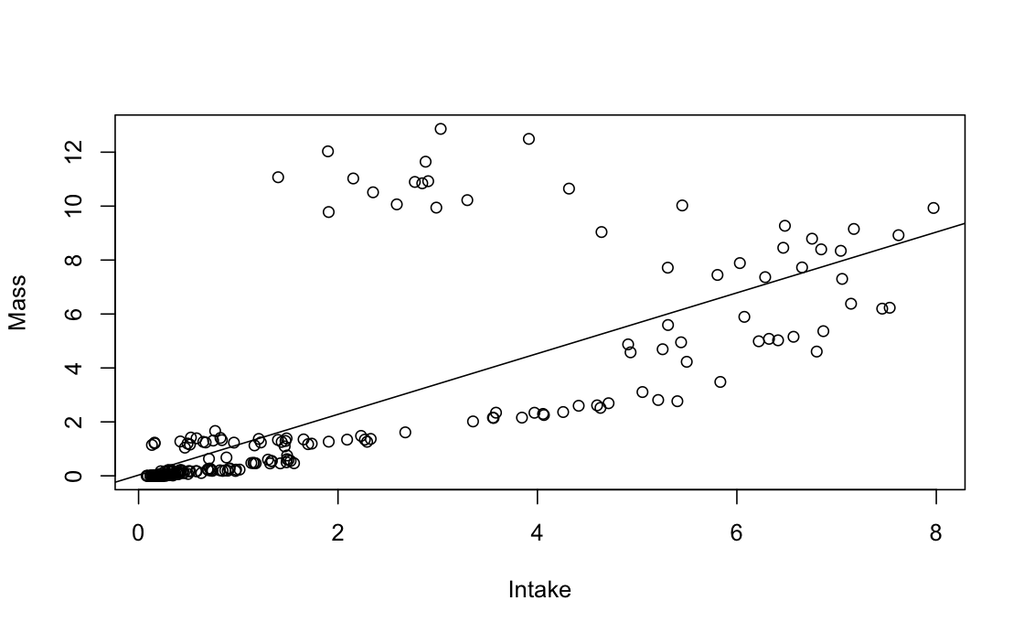

```r
# Exercise 31
CatLM = lm(Mass~Intake, data = Caterpillars)
plot(Mass~Intake, data = Caterpillars)
abline(CatLM)
```

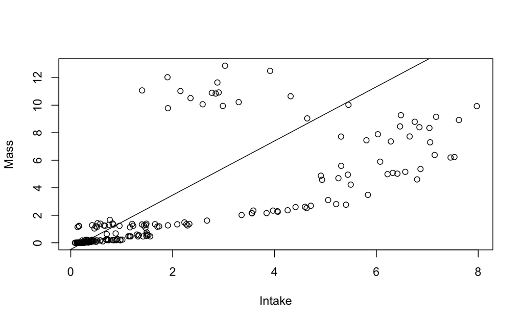

```r
CatLog = lm(LogMass~LogIntake, data = Caterpillars)
plot(Mass~Intake, data = Caterpillars)
abline(CatLog)
```

For either of these relationships a linear model should not be used. The data points are heavily clustered in the bottom left of the graph and then further along the x-axis the values are all over the place meaning that a linear model would not be a good model for this data.

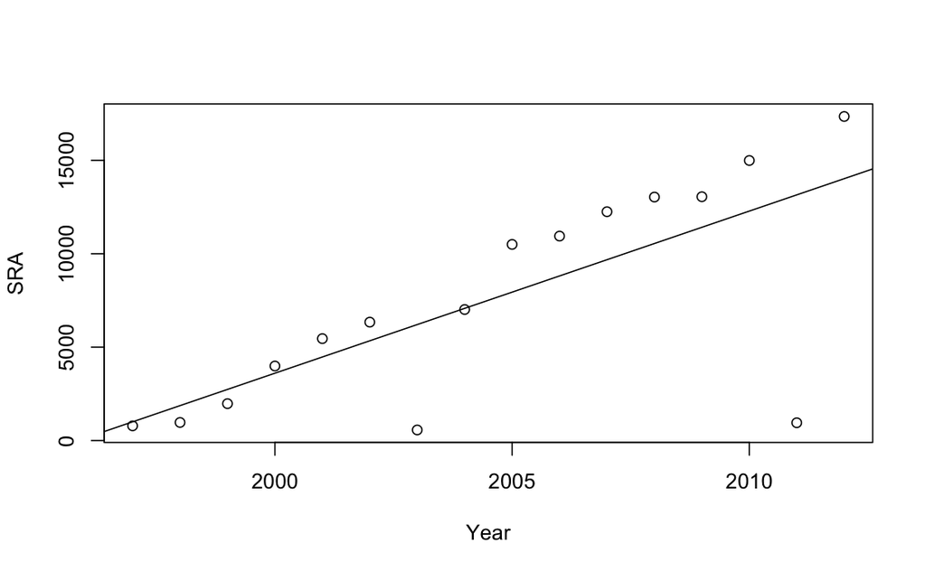

```r
# Exercise 47
RetirementLM = lm(SRA~Year, data = Retirement)
plot(SRA~Year, data = Retirement)
abline(RetirementLM)
```

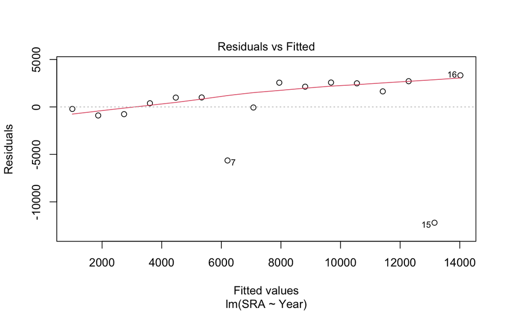

```r
plot(RetirementLM, 1)
```

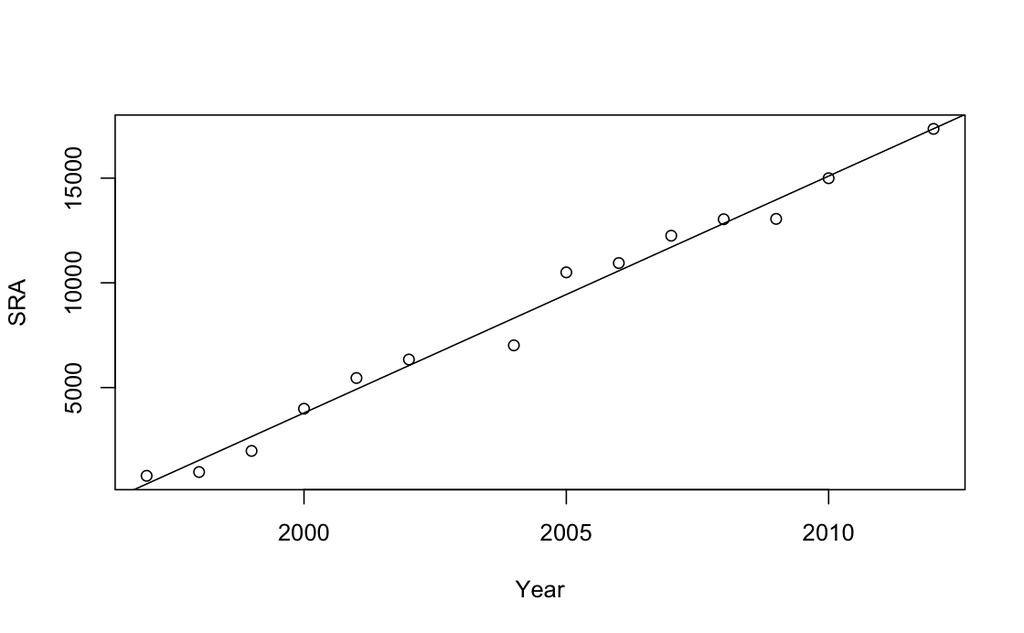

```r
Dropped = Retirement[-c(7,15),]
DroppedLM = lm(SRA~Year, data = Dropped)
plot(SRA~Year, data = Dropped)
abline(DroppedLM)
```

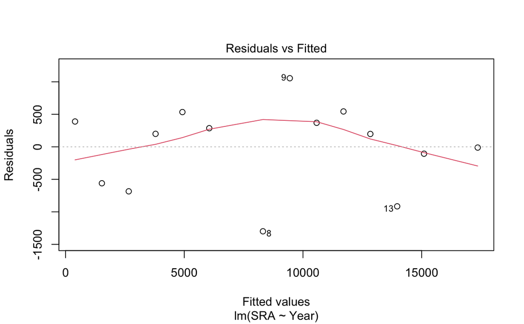

```r
plot(DroppedLM, 1)
```

The two years are 2003, 2011 with residuals of -5642.72 and -12200.96. When looking at both the regular graph and the residual graph these years are clear outliers being nowhere near the residual/lsrl line. When dropping the two years from the data set the model fits much better onto the datapoints. This is proven on the regular plot where most all the points are on the lsrl line or extremely close to the lsrl line. This is also true for the residual plot as there is consistent variance throughout the graph along with the points being close to the mean residual line.

Page 250

```r
# Chapter 2 Exercises
# 15, 17, 23
```

```r
# Exercise 15
CerealLM = lm(Calories~Sugar, data = Cereal)
summary(CerealLM)
```

```
Call:
lm(formula = Calories ~ Sugar, data = Cereal)

Residuals:
    Min      1Q  Median      3Q     Max
-37.428  -9.832   0.245   8.909  40.322

Coefficients:
            Estimate Std. Error t value Pr(>|t|)
(Intercept)  87.4277     5.1627  16.935   <2e-16 ***
Sugar         2.4808     0.7074   3.507   0.0013 **
---
Signif. codes:  0 ‘***’ 0.001 ‘**’ 0.01 ‘*’ 0.05 ‘.’ 0.1 ‘ ’ 1

Residual standard error: 19.27 on 34 degrees of freedom
Multiple R-squared:  0.2656,    Adjusted R-squared:  0.244
F-statistic:  12.3 on 1 and 34 DF,  p-value: 0.001296
```

```r
confint(CerealLM, level = 0.95)
```

```
                2.5 %    97.5 %
(Intercept) 76.935859 97.919521
Sugar        1.043205  3.918421
```

A. Using a t-test we are trying to see if there is a linear relationship between sugar and calories in cereal. The test statistic is 3.507. The Ho = 0 and states that there is no relationship between sugar and calories in cereal. The Ha != 0 and states that there is a relationship between sugar and calories. The p-value of this relationship is 0.001296. Since this value is bigger than 0 we reject the null hypothesis and can confirm that there is a linear relationship between sugar and calories.

B. 95% confident for every gram of sugar in cereal there is between a 1.04 to 3.92 increase in calories.

```r
# Exercise 17
cor(LewyDLBad$MMSE,LewyDLBad$APC)
```

```
[1] 0.6000182
```

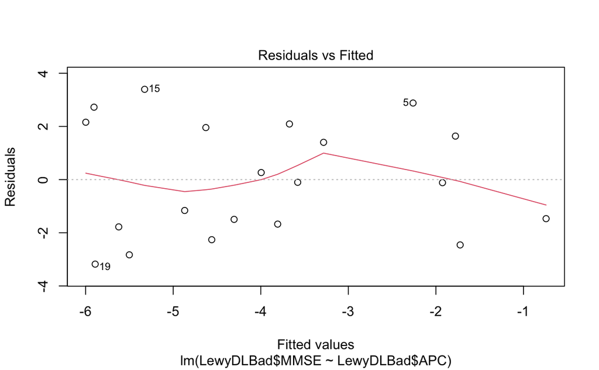

```r
LewyLM = lm(LewyDLBad$MMSE~LewyDLBad$APC)
plot(LewyLM, 1)
```

```r
summary(LewyLM)
```

```
Call:
lm(formula = LewyDLBad$MMSE ~ LewyDLBad$APC)

Residuals:
    Min      1Q  Median      3Q     Max
-3.1791 -1.6991 -0.1081  1.9911  3.3963

Coefficients:
              Estimate Std. Error t value Pr(>|t|)
(Intercept)    -2.4359     0.6858  -3.552  0.00228 **
LewyDLBad$APC   1.3444     0.4225   3.182  0.00516 **
---
Signif. codes:  0 ‘***’ 0.001 ‘**’ 0.01 ‘*’ 0.05 ‘.’ 0.1 ‘ ’ 1

Residual standard error: 2.184 on 18 degrees of freedom
Multiple R-squared:   0.36, Adjusted R-squared:  0.3245
F-statistic: 10.13 on 1 and 18 DF,  p-value: 0.005161
```

```r
confint(LewyLM, level = 0.90)
```

```
                     5 %      95 %
(Intercept)   -3.6251781 -1.246683
LewyDLBad$APC  0.6117672  2.076951
```

A. The r between MMSE and APC is 0.6 which is pretty strong indicating a linear relationship between these two values. B. When looking at the residual plot there is a good relationship as the variance throughout the graph is consistent and there is no significant clustering at any point. C. The estimated slope is 1.3444 and the standard error is 0.4225 D. 90% confident for every APC there is between a 0.61 to 2.08 increase in MMSE. This interval does not contain 0. This confidence interval is related to part A due to the confidence interval being small meaning that there is a close relationship between these two variables proving the linear relationship.

```r
# Exercise 23
USstamps = USstamps[-c(1:4),]

USLM = lm(Price~Year, data = USstamps)
summary(USLM)
```

```
Call:
lm(formula = Price ~ Year, data = USstamps)

Residuals:
    Min      1Q  Median      3Q     Max
-2.9232 -0.9478  0.1195  1.1899  4.5325

Coefficients:
              Estimate Std. Error t value Pr(>|t|)
(Intercept) -1.647e+03  4.686e+01  -35.15   <2e-16 ***
Year         8.410e-01  2.357e-02   35.68   <2e-16 ***
---
Signif. codes:  0 ‘***’ 0.001 ‘**’ 0.01 ‘*’ 0.05 ‘.’ 0.1 ‘ ’ 1

Residual standard error: 1.737 on 19 degrees of freedom
Multiple R-squared:  0.9853,    Adjusted R-squared:  0.9845
F-statistic:  1273 on 1 and 19 DF,  p-value: < 2.2e-16
```

```r
cor(USstamps$Price, USstamps$Year)
```

```
[1] 0.9926204
```

```r
anova(USLM)
```

```
Analysis of Variance Table

Response: Price
          Df Sum Sq Mean Sq F value    Pr(>F)
Year       1 3841.2  3841.2  1273.1 < 2.2e-16 ***
Residuals 19   57.3     3.0
---
Signif. codes:  0 ‘***’ 0.001 ‘**’ 0.01 ‘*’ 0.05 ‘.’ 0.1 ‘ ’ 1
```

Page 401

```r
# Chapter 3 Exercises
# 21, 23, 29, 31, 35
```

```r
# Exercise 21
MathEnrollment = MathEnrollment[-c(3),]

MathLM = lm(Spring~Fall+AYear, data = MathEnrollment)
summary(MathLM)
```

```
Call:
lm(formula = Spring ~ Fall + AYear, data = MathEnrollment)

Residuals:
     Min       1Q   Median       3Q      Max
-16.1945  -9.3982   0.3212   5.8503  18.2036

Coefficients:
              Estimate Std. Error t value Pr(>|t|)
(Intercept) -1.172e+04  2.686e+03  -4.361  0.00331 **
Fall        -1.007e+00  2.041e-01  -4.933  0.00169 **
AYear        6.107e+00  1.337e+00   4.566  0.00258 **
---
Signif. codes:  0 ‘***’ 0.001 ‘**’ 0.01 ‘*’ 0.05 ‘.’ 0.1 ‘ ’ 1

Residual standard error: 13.37 on 7 degrees of freedom
Multiple R-squared:  0.871, Adjusted R-squared:  0.8342
F-statistic: 23.64 on 2 and 7 DF,  p-value: 0.0007704
```

```r
anova(MathLM)
```

```
Analysis of Variance Table

Response: Spring
          Df Sum Sq Mean Sq F value   Pr(>F)
Fall       1 4721.1  4721.1  26.423 0.001338 **
AYear      1 3725.8  3725.8  20.852 0.002585 **
Residuals  7 1250.7   178.7
---
Signif. codes:  0 ‘***’ 0.001 ‘**’ 0.01 ‘*’ 0.05 ‘.’ 0.1 ‘ ’ 1
```

A. The percent of variation between Spring and Fall+AYear is 87.1% B. The size of typical error for this model is 13.4 C. The F-stat = 23.64, F-stat fromthe F distribution table is 3.2574 which is less than the ANOVA F-stat. Knowing this we reject the null. D. Using an F-test we are trying to see if there is a relationship between Spring enrollment and Fall+Year enrollment. The Ho = 0 and states that there is no relationship between Spring enrollment and Fall+Year enrollment. The Ha != 0 and states that there is a relationship between Spring enrollment and Fall+Year enrollment. The p-values in this relationship are 0.00138 and 0.002585. Since these values are bigger than 0 we can reject the null hypothesis and can confirm that there is a relationship between Spring enrollment and Fall+Year enrollment.

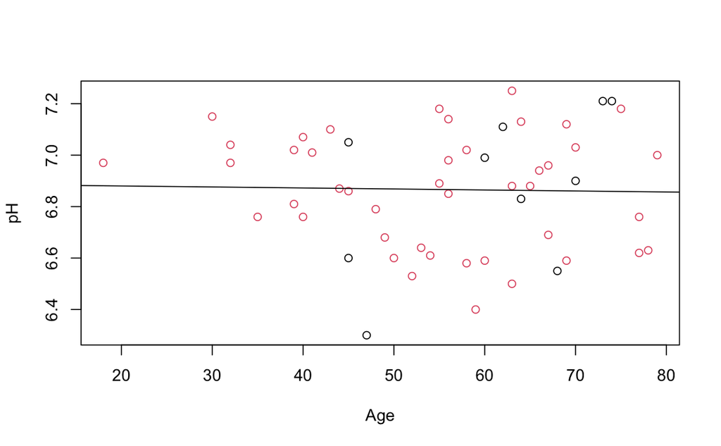

```r
# Exercise 23
plot(pH~Age, col = Sex, data = BrainpH)

BrainLM = lm(pH~Age, data = BrainpH)
abline(BrainLM)
```

```r
cor(BrainpH$pH, BrainpH$Age)
```

```
[1] -0.02359256
```

```r
MaleLM = lm(BrainpH$pH~Age+(Sex=="M"), data = BrainpH)
FemaleLM =  lm(pH~Age+(Sex=="F"), data = BrainpH)
MaleLM
```

```
Call:
lm(formula = BrainpH$pH ~ Age + (Sex == "M"), data = BrainpH)

Coefficients:
   (Intercept)             Age  Sex == "M"TRUE
     6.9025758      -0.0004535      -0.0134258
```

```r
FemaleLM
```

```
Call:
lm(formula = pH ~ Age + (Sex == "F"), data = BrainpH)

Coefficients:
   (Intercept)             Age  Sex == "F"TRUE
     6.8891500      -0.0004535       0.0134258
```

```r
# Exercise 29
plot(PctReport~Period, data = Jurors, col = Year)

JurorLM = lm(PctReport~Period, data = Jurors)
#abline(JurorLM)
cor(Jurors$PctReport, Jurors$Period)
```

```
[1] -0.4377677
```

```r
Year1 = lm(PctReport~Period+(Year=="1998"), data = Jurors)
Year2 = lm(PctReport~Period+(Year=="2000"), data = Jurors)
Year1
```

```
Call:
lm(formula = PctReport ~ Period + (Year == "1998"), data = Jurors)

Coefficients:
       (Intercept)              Period  Year == "1998"TRUE
           94.9162             -0.7169            -17.8346
```

```r
Year2
```

```
Call:
lm(formula = PctReport ~ Period + (Year == "2000"), data = Jurors)

Coefficients:
       (Intercept)              Period  Year == "2000"TRUE
           77.0816             -0.7169             17.8346
```

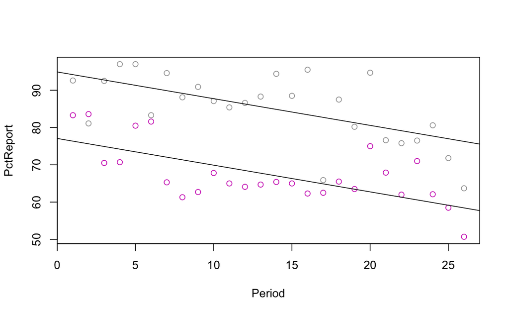

```r
abline(Year1)
abline(Year2)
```

```r
BigMod = lm(PctReport~Period+Year+Period*Year, data = Jurors)
BigMod
```

```
Call:
lm(formula = PctReport ~ Period + Year + Period * Year, data = Jurors)

Coefficients:
(Intercept)       Period         Year  Period:Year
 -1.905e+04    9.643e+01    9.573e+00   -4.860e-02
```

```r
# Exercise 31
plot(Survey2~Survey1, col = Gender, data = Handwriting)
HandLM = lm(Survey2~Survey1+factor(Gender), data = Handwriting)
HandLM
```

```
Call:
lm(formula = Survey2 ~ Survey1 + factor(Gender), data = Handwriting)

Coefficients:
    (Intercept)          Survey1  factor(Gender)1
        43.6305           0.3133           3.4623
```

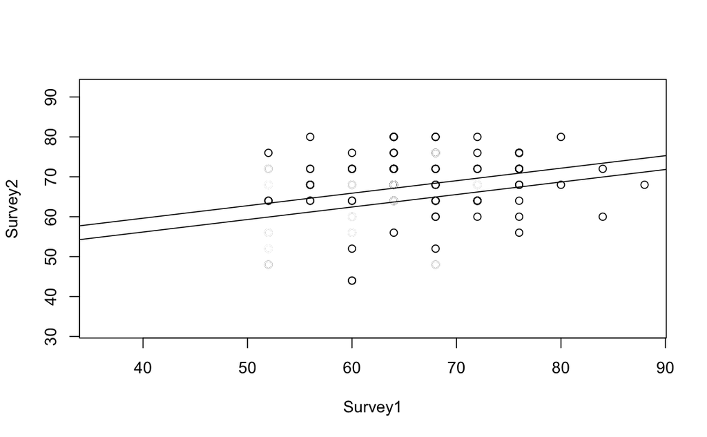

```r
Men = lm(Survey2~Survey1+(Gender=="1"), data = Handwriting)
Women = lm(Survey2~Survey1+(Gender=="0"), data = Handwriting)
abline(Men)
abline(Women)
```

```r
Men
```

```
Call:
lm(formula = Survey2 ~ Survey1 + (Gender == "1"), data = Handwriting)

Coefficients:
      (Intercept)            Survey1  Gender == "1"TRUE
          43.6305             0.3133             3.4623
```

```r
Women
```

```
Call:
lm(formula = Survey2 ~ Survey1 + (Gender == "0"), data = Handwriting)

Coefficients:
      (Intercept)            Survey1  Gender == "0"TRUE
          47.0928             0.3133            -3.4623
```

```r
GendSurv = lm(Survey2~Survey1+factor(Gender)+Gender*Survey1, data = Handwriting)
GendSurv
```

```
Call:
lm(formula = Survey2 ~ Survey1 + factor(Gender) + Gender * Survey1,
    data = Handwriting)

Coefficients:
    (Intercept)          Survey1  factor(Gender)1           Gender   Survey1:Gender
        37.4606           0.4200          16.9725               NA          -0.2171
```

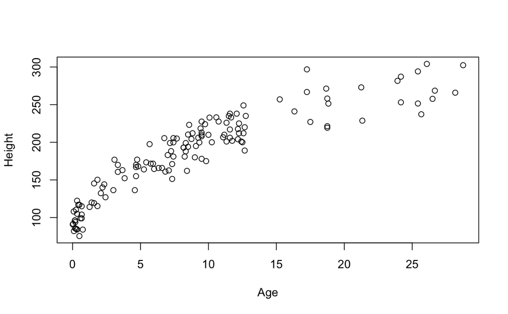

```r
# Exercise 35
plot(Height~Age, data = ElephantsFB)
```

```r
Age2 = ElephantsFB$Age^2
EleQuad = lm(Height~Age+Age2, data = ElephantsFB)
EleQuad
```

```
Call:
lm(formula = Height ~ Age + Age2, data = ElephantsFB)

Coefficients:
(Intercept)          Age         Age2
   100.2122      13.3833      -0.2643
```

```r
Elephant = 100.2 + 13.38*15 - 0.26*15^2
Elephant
```

```
[1] 242.4
```

A. The scatter plot of Height and Age has a big curve that looks similar to a square root function B. 100.2 + 13.38(Age) - 0.26(Age)^2 C. 242.4 centimeters for a 15 year old elephant.

Page 517

```r
# Chapter 4 Exercises
# 13, 15
```

# Exercise 13

The mean birth weight for babies with White mothers is 117.87 ounces, the mean birth weight for babies with Black mothers is 110.56 ounces, the mean birth weight for babies with Hispanic mothers is 118.52 ounces, and the mean birth weight for babies with other mothers is 117.14 ounces. White mothers is the base while the other races in this model is based off of White Mothers.

```r
# Exercise 15
BloodLM1 = lm(SystolicBP~Overwt, data = Blood1)
BloodLM2 =lm(SystolicBP~factor(Overwt), data = Blood1)

BloodLM1
```

```
Call:
lm(formula = SystolicBP ~ Overwt, data = Blood1)

Coefficients:
(Intercept)       Overwt
    136.229        8.437
```

```r
BloodLM2
```

```
Call:
lm(formula = SystolicBP ~ factor(Overwt), data = Blood1)

Coefficients:
    (Intercept)  factor(Overwt)1  factor(Overwt)2
        136.316            8.051           16.866
```

Quantitative model = 136.23 + 8.44(Overweight) Factor model = 136.32 + 8.05(Overweight) + 16.87(Obese) Overall these models are very similiar with the intercepts being nearly identical and the slopes not being too far off from each other.

Page 643

```r
# Chapter 5 Exercises
# 27, 37, 45
```

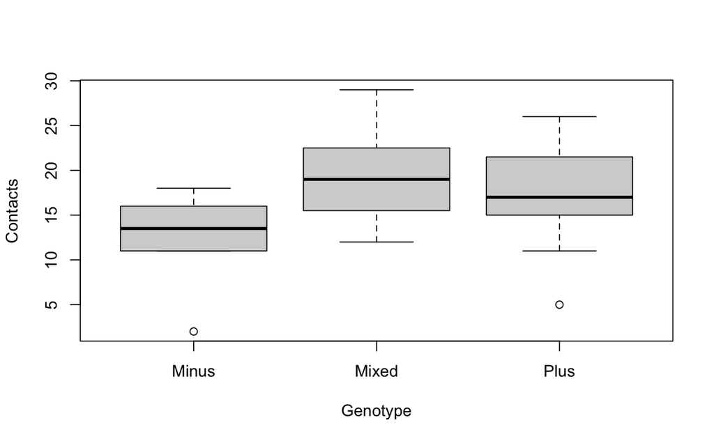

```r
# Exercise 27
boxplot(Contacts~Genotype, data = MouseBrain)
```

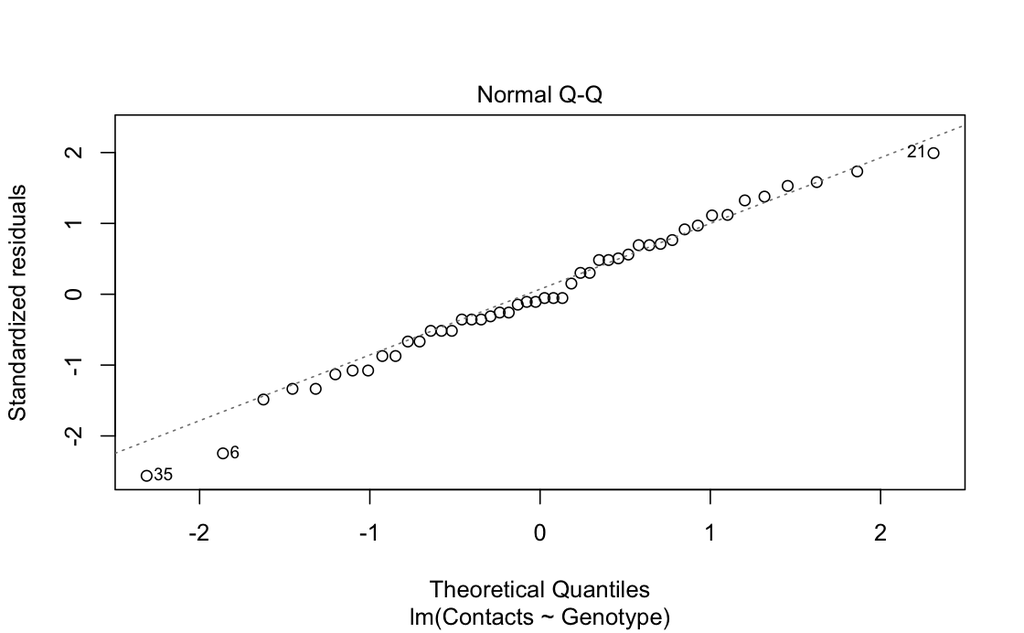

```r
MouseLM = lm(Contacts~Genotype, data = MouseBrain)
plot(MouseLM, 2)
```

A. The minus genotype has the lowest min, median, and max with also the smallest IQR compared to the other genotypes. The mixed genotype on the other hand has the highest min, median, and max with an IQR that’s about the same with the plus genotype. B. When looking at the qq plot of the model the points are very linear, meeting the conditions required for ANOVA

```r
# Exercise 37
anova(MouseLM)
```

```
Analysis of Variance Table

Response: Contacts
          Df Sum Sq Mean Sq F value   Pr(>F)
Genotype   2  285.4 142.698    5.66 0.006418 **
Residuals 45 1134.5  25.212
---
Signif. codes:  0 ‘***’ 0.001 ‘**’ 0.01 ‘*’ 0.05 ‘.’ 0.1 ‘ ’ 1
```

Using an F-test we are trying to see if there is a relationship between Genotype and Contacts. The Ho = 0 and states that there is no relationship between Genotype and Contacts. The Ha != 0 and states that there is a relationship between Genotype and Contacts. The p-value of this relationship is 0.006418. Since this value is bigger than 0 we reject the null hypothesis and can confirm that there is a relationship between Genotype and Contacts.

```r
# Exercise 45
Fisher = LSD.test(MouseBrain$Contacts, MouseBrain$Genotype, 2, 142.698)
Fisher
```

```
$statistics
  MSerror Df     Mean       CV
  142.698  2 17.20833 69.41769

$parameters
        test p.ajusted              name.t ntr alpha
  Fisher-LSD      none MouseBrain$Genotype   3  0.05

$means
      MouseBrain$Contacts      std  r       LCL      UCL Min Max  Q25  Q50   Q75
Minus            12.70000 4.522782 10 -3.553438 28.95344   2  18 11.0 13.5 15.75
Mixed            19.26316 4.794002 19  7.471675 31.05464  12  29 15.5 19.0 22.50
Plus             17.52632 5.460651 19  5.734833 29.31780   5  26 15.0 17.0 21.50

$comparison
NULL

$groups
      MouseBrain$Contacts groups
Mixed            19.26316      a
Plus             17.52632      a
Minus            12.70000      a

attr(,"class")
[1] "group"
```

Page 1008

```r
# Chapter 8 Exercises
# 3, 51, 55
```

```r
# Exercise 3
leveneTest(NCbirths$BirthWeightOz, factor(NCbirths$MomRace))
```

```
Levene's Test for Homogeneity of Variance (center = median)
        Df F value Pr(>F)
group    3  1.1163 0.3413
      1446
```

```r
# Exercise 51
NCbirths$Dummy = ifelse(NCbirths$MomRace == "white", "0", ifelse(NCbirths$MomRace == "hispanic", "1", ifelse(NCbirths$MomRace == "black", "2", "3")))

BirthsMod = lm(BirthWeightOz~Dummy, data = NCbirths)
BirthsMod
```

```
Call:
lm(formula = BirthWeightOz ~ Dummy, data = NCbirths)

Coefficients:
(Intercept)       Dummy1       Dummy2       Dummy3
   117.8720       0.6463      -7.3087      -0.7261
```

A. 3 B. The mean birth weight for babies with white mothers is 117.87 Oz, the mean birth weight for babies with hispanic mothers is 118.52 Oz, the mean birth weight for babies with black mothers is 110.56 Oz, the mean birth weight for babies with other mothers is 117.15 Oz C. The tables are the same therefore no further analysis can be done.

```r
# Exercise 55
```

[output not shown]

Page 1167

```r
# Chapter 9 Exercises
# 21, 33
```

[output not shown]